# gfx

This is just a collection of random notes picked up from various sources on the web. If you want to study 3D graphics one of the best places to start is [Computer Graphics](https://www.youtube.com/playlist?list=PL_w_qWAQZtAZhtzPI5pkAtcUVgmzdAP8g). This is just an attempt to make various pieces of information more real and hopefully more understandable as I try to document the steps I follow to make sense of it all.

```python
import numpy as np
import matplotlib.pyplot as plt
%matplotlib inline
```

### vector space

You can add any two vectors $V_1 + V_2 = V_3$. You can also multiply anything in the vector space by a constant $CV_1 = V_2$. There's some rules so things make sense. This is hardcore stuff that has eventually has to do with monads and tends to get really complicated. So we kind of forget about it for now. It deals with stuff like *commutative*, *associative* and *distributive* laws and is much fun but we won't worry about it too much for now. For now, we can just say that stuff is there to make sure that any calculatios we do make sense.

Frames are kind of little coordinate systems. Like coordinate systems, frames have an origin $O$.

Besides vectors there also these things called points. There's two things we can do with points:

- We can add a vector to a point and get another point: $Q = P + \vec{V}$
- We can substract two points and get a vector: $\vec{V} = Q - P$

Using $Q = P + \alpha\vec{V}$ we can calculate any point on a line between P and Q.

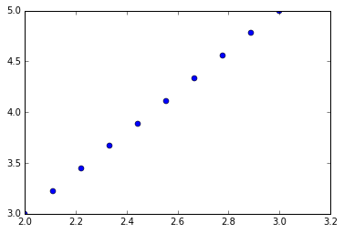

```python
P1 = np.array([2,3])
V = np.array([1,2])
a = np.linspace(0, 1, 10)
x = P1[0] + a * V[0]
y = P1[1] + a * V[1]
plt.plot(x, y, 'bo')
```

We can also think of this another way. If we have two points $P_1$ and $P_2$ then we can say that $P_t = P_1 + t(P_2 - P_1)$. Now considering that one of rules of the vector space is that when we substract two points we get a vector so that $V = P_2 - P_1$ then this this is equivalent to the above: $P_t = P_1 + t\vec{V}$.

However, there's another way to write this: $P_t = (1 - t)P_1 + tP_2$.

We can see that this is true by expanding it: $(1 - t)P_1 + tP_2 = P_1 - tP_1 + tP_2 = P_1 + t(P_2 - P_1)$.

Let's make sure by we're sane by checking our results in `python`. In the code below, `u` is calculated with our initial version $P_1 + t(P_2 - P_1)$, `v` is calculated using the expanded version $P_1 - tP_1 + tP_2$ and `w` is calculated using our refactored version $(1 - t)P_1 + tP_2$.

```python
p1 = 0
p2 = 5
t = 0.43
u = p1 + t * (p2 - p1)      # naïve
v = p1 - t * p1 + t * p2    # expanded
w = (1 - t) * p1 + t * p2   # factored
print("u=%0.2f, v=%0.2f and w=%0.2f" % (u,v,w))
```

```
u=2.15, v=2.15 and w=2.15
```

#### affine combination

Why do we want to write it like $(1 - t)P_1 + tP_2$? Well, now we have something called an **affine combination** which basically means that we have something like $P_t = {t_1}P_1 + {t_2}P_2 + {t_3}P_3$ where $t_1 + t_2 + t_3 = 1$. We can see this is true by saying that $t_1 = 1 - t$ and $t_2 = t$ so we we can rewrite our refactored version as $t_1P_1 + t_2P_2$. Now we say $t_1 + t_2 = 1$ and if we expand that back we get $t_1 + t_2 = 1 - t + t = 1$.

```python
t1 = lambda t: 1 - t
t2 = lambda t: t
# verify using t0 = 0, t1 = 1/10, t2 = 2/10 tn = n/10 where 0 <= t < 1
t = np.linspace(0, 1, 10)
# this should sum up to 1 for all components of the t vector
t1(t) + t2(t)
```

```
array([ 1.,  1.,  1.,  1.,  1.,  1.,  1.,  1.,  1.,  1.])
```

Vectors and points are called **affine space**. We'll encounter this word **affine** more often.

Before we can go further we'll have to do a pretty huge plot function that draws the triangle that we are gonna work with for the next few sections.

```python
# P1, P2 and P3 are the vertices of our triangle
P1 = 0, 1
P2 = 2, 5
P3 = 4, 2

# P is a point that lies in the space defined
# by the vertices P1, P2 and P3
P = 1.8, 2.9
```

```python
def plot_example():
    """Plots a triangle with annotations using vertices P1, P2 and P3."""

    # Plot the 3 edges of our triangle
    for p in [(P1, P2), (P2, P3), (P3, P1)]:
        p0, p1 = p
        plt.plot((p0[0], p1[0]), (p0[1], p1[1]), 'b')

    # Plot 3 black dots `ko` at the vertices of our triangle
    for p in [P1, P2, P3]:
        px, py = p
        plt.plot(px, py, 'ko')

    # Plot `P`
    plt.plot(P[0], P[1], 'ro')

    # We'll grab the axes for some fancy annotation
    ax = plt.axes()

    # Set the limites so we'll have some padding around our triangle
    ax.set_xlim(-1.0, 5.0)
    ax.set_ylim(0, 6.0)

    # Make sure nothing is skewed
    ax.set_aspect(1.0)

    # Plot our vertice annotations
    ax.annotate('$P_1$', P1, xytext=(P1[0] - 0.5, P1[1]))
    ax.annotate('$P_2$', P2, xytext=(P2[0] + 0.25, P2[1]))
    ax.annotate('$P_3$', P3, xytext=(P3[0] + 0.25, P3[1]))

    # Plot our vector annotations
    ax.annotate(r'$\vec{a}$', (0.5, 3))
    ax.annotate(r'$\vec{b}$', (3.25, 3.5))
    ax.annotate(r'$\vec{c}$', (2, 1))

    # Plot the annotation for P
    ax.annotate('P', P, xytext=(P[0] + 0.25, P[1]))
```

Now all this stuff is especially useful when we want to start to calculating points in a triangle. Consider the point $P$ below.

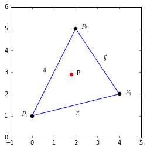

```python
plot_example()
```

```python
P3 = 4,2
P1 = 0,1

def f(t, p0, p1):
    return (1 - t) * p0 + t * p1

f(0.3, 0, 4)
```

```
1.2
```

For now we just have a linear interpolation. We could plot this together with our triangle from before.

TODO: Barycentric coördinates. Coördinates of triangles.

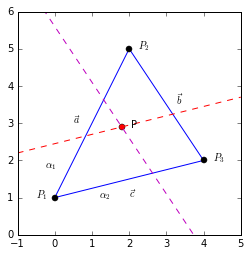

```python
plot_example()
f1 = lambda x: 1/4 * x + 1
f2 = lambda x: -1.5 * x + 1
x = np.linspace(-1, 5, 5)
f_c = f1(x) - f1(P[0]) + P[1]
plt.plot(x, f_c, 'r--')
f_b = f2(x) - f2(P[0]) + P[1]
plt.plot(x, f_b, 'm--')
ax = plt.axes()
ax.annotate(r'$\alpha_1$', (-0.25, 1.8))
ax.annotate(r'$\alpha_2$', (1.2, 1))
```

The above plot is a little convoluted. First we notice the triangle from before. Notice $\alpha_1$ and $\alpha_2$ which resemble the distance from $P_1$ to $P_2$ and the distance from $P_1$ to $P_3$ to where to the dashed lines cross. The two dashed lines are somewhat chosen at random. We could have chosen any two crossing lines within the space of the triangle and in fact you could vary this these points for some nice effects. For now this seems like a natural choice.

- TODO: this science is probably related to *triangulating* a position
- TODO: lookup if it this in fact related to triangulation and how this works